# Figures for Bacterial Community Dynamics in an Oyster Hatchery in Response to Probiotic Treatment

# Figure 5. Trial 1 Vibrionales Relative Read Abundances and Diversity

This figure will plot the relative percent abundance of Vibrionales in each group, and the inter-Vibrionales diversity. We’ll use the order data already imported, then import a Vibrio biom file to calculate the Vibrio diversity per sample.

First, let’s plot the percent number of Vibrionales reads per group.

```r
# use order data already imported for all samples in trial 1:
#abund_table_1 and meta_table_1
# merge them together!
trial1order<-as.data.frame(c(meta_table_t1, abund_table_t1))
trial1order$Sample<-trial1order$taxa

# group and calculate means of vibrionales
grouped_trial1 <- group_by(trial1order, Type, Day, Treatment)
trial1_vibrio_means <- summarise(grouped_trial1,
                         meanvib = mean(Bacteria.Proteobacteria.Gammaproteobacteria.Vibrionales, na.rm=TRUE),
                         stdevvib = sd(Bacteria.Proteobacteria.Gammaproteobacteria.Vibrionales, na.rm=TRUE))

#add some room for error bars
trial1_vibrio_means$y_max<-(trial1_vibrio_means$meanvib*1.5)

# and then plot it!
plotv<-ggplot(trial1_vibrio_means, aes(as.factor(Day),meanvib, fill=Treatment))+
  geom_bar(stat="identity", aes(fill=Treatment), position="dodge")+
  geom_errorbar(aes(ymin=pmax(meanvib-stdevvib,0), ymax=meanvib+stdevvib),
                width=0.2, position=position_dodge(.9))+
  facet_wrap(~Type, scales="free")+
  labs(y="Normalized Percent Abundance \nof Vibrionales Reads", x="Day")+
  scale_fill_manual(values=c("light blue", "dark red"))+
  theme(plot.margin = unit(c(0, 0, 0, 0), "cm"),strip.text = element_text(size = 14),
        axis.text = element_text(size = 10),
        axis.title = element_text(size = 10),legend.position = "none")+
  scale_y_continuous(labels = scales::percent_format(accuracy=.01))+
  ggtitle("Relative Vibrionales Adundance per Sample Type in Trial 1")+
  geom_blank(aes(y = y_max))
```

Now, we’ll import the Vibrionales reads by species and plot the diversities.

```r
vibrio_biom = import_biom("Trial1_Vibrio_2231614vamps_sparse_matrix_custom_norm_maximum.biom")

meta_table_t1$diversity<-estimate_richness(vibrio_biom, measures=c("simpson"))

diversev<- ggplot(meta_table_t1, aes(as.factor(Day),diversity$Simpson))+
  geom_boxplot(aes(fill=Treatment), position="dodge")+
  facet_wrap(~Type, scales="free")+
  labs(y="Simpson's Diversity Index ", x=NULL)+
  scale_fill_manual(values=c("light blue", "dark red"))+
  theme(strip.text = element_text(size = 14), axis.text = element_text(size = 10),
        axis.title = element_text(size = 12),legend.position = "none")+
  scale_y_continuous(limits=c(0,0.8))+
  ggtitle("Vibrionales Simpson's Diversity per Sample Type in Trial 1")
```

And then we plot them together:

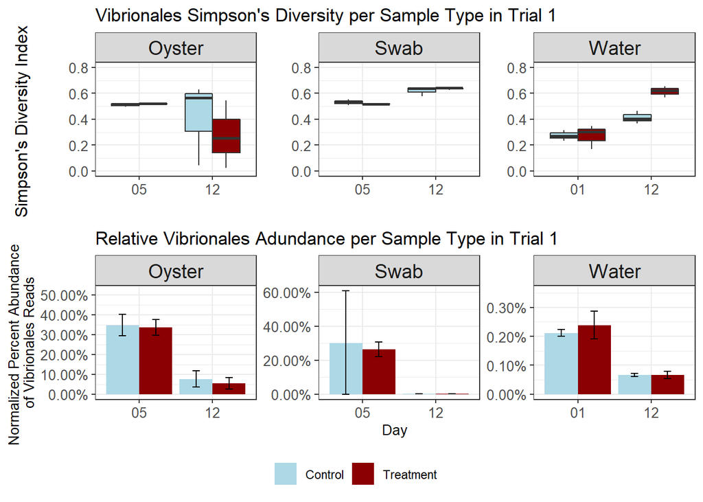

```r
vibrioplots<-cowplot::plot_grid(diversev, plotv, nrow=2, align = 'hv',axis = 'b')

cowplot::plot_grid(vibrioplots, legendabund, nrow=2, rel_heights = c(8,1))
```

**Figure 5.** Effect of treatment, time, and samples type on Simpson’s Index of Diversity for Vibrionales (a, boxplots) and Total Vibrionales relative percent read abundance (b, bar graph). Representative data from Trial 1 (n=3 tanks per treatment). Note different scales for (b).

# Figure 6. Vibrionales Oligotyping Percentages

This figure was exported directly from VAMPS.

# Figure 7. Trial 3 Co-occurrence Network

This figure shows the relatedness of taxa based on their relative abundances and treatment group. We built the relationship table using these commands in R, then exported it to Cytoscape for viewing.

```r
# import Trial 3 Order data as a biom file
ord3_biom = import_biom("Trial3_695Con_apost_8393634vamps_sparse_matrix_orderx_norm_maximum.biom")
# build the network
igorder3 = make_network(ord3_biom, type="taxa",distance="bray", max.dist = 0.5,
                        keep.isolates=FALSE)

plot_network(igorder3)
plot.igraph(igorder3, mark.shape = 0.1)
summary(igorder3)

# Export as a csv
write.csv(as_long_data_frame(igorder3), file="LongDataFrame.csv")
# Then delete all but columns D and E --> Interactions.csv
# import into cyctoscape
```

# Supplementary Figures

### Figure S1. Rarefaction Curves

This figure shows the rarefaction curves for all the water samples. We use non-normalized data to rarefy and plot.

```r
#import pre-normalized data at the order level
waterdata<-read.xlsx("TAXA_AllTrials_Water_Order_trans.xlsx")
#determine number of orders
S<-specnumber(waterdata)
#rarefy data
raremax<-min(rowSums(waterdata))
#define colors and linetypes based on trial number
colors<-c("blue","blue","blue","blue","blue","blue","blue","blue","blue","blue","blue","blue",
         "forestgreen","forestgreen","forestgreen","forestgreen","forestgreen","forestgreen",
         "forestgreen","forestgreen","forestgreen","forestgreen","forestgreen","forestgreen",
         "hotpink","hotpink","hotpink","hotpink","hotpink","hotpink","hotpink","hotpink","hotpink",
         "hotpink","hotpink","hotpink",
         "hotpink","hotpink","hotpink","hotpink","hotpink","hotpink")
lty <- c("solid","solid","solid","solid","solid","solid","solid","solid","solid","solid",
         "solid","solid","dashed","dashed","dashed","dashed","dashed","dashed","dashed",
         "dashed","dashed","dashed","dashed","dashed",
         "dotdash","dotdash","dotdash","dotdash","dotdash","dotdash","dotdash","dotdash",
         "dotdash","dotdash","dotdash","dotdash",
         "dotdash","dotdash","dotdash","dotdash","dotdash","dotdash")

#put plotting parameters into pars
pars <- expand.grid(col = colors, lty = lty, stringsAsFactors = FALSE)
#generate rarefaction curves - THIS STEP TAKES A LITTLE WHILE TO RUN.
outw <- with(pars[1:42,], rarecurve(waterdata, step = 20, sample = raremax, col = colors, lty=lty, label = FALSE))
```

```r
# determine limits of the graph
Nmax <- sapply(outw, function(x) max(attr(x, "Subsample")))
Smax <- sapply(outw, max)
```

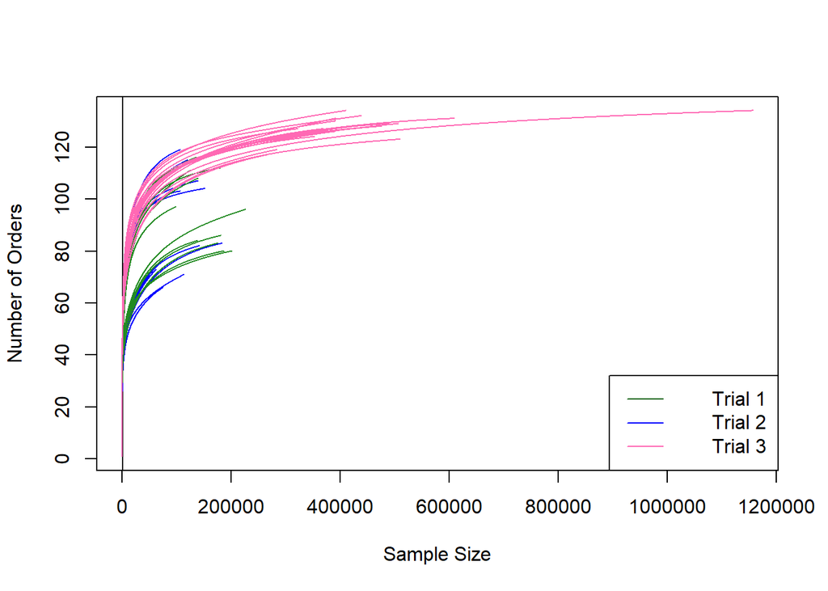

```r
# plot the curves
plot.new()
plot(c(1, max(Nmax)), c(1, max(Smax)), xlab = "Sample Size",
     ylab = "Number of Orders", type = "n")
abline(v = raremax)
for (i in seq_along(outw)) {
  N <- attr(outw[[i]], "Subsample")
  with(pars, lines(N, outw[[i]], col = col[i], lty = lty[i]))
}
temp <- legend("bottomright", legend = c(" ", " "," "), lty=1,
               text.width = strwidth("1,000,000"),
               col=c("darkgreen","blue", "hotpink"), xjust = 1, yjust = 1)
text(temp$rect$left + temp$rect$w, temp$text$y,c("Trial 1", "Trial 2", "Trial 3"), pos = 2)
```

**Supplementary Figure 1.** Rarefaction curve from all water samples from all three Trials based on taxonomic classification at the order level.

### Figure S2. Trial 1 Top 20 Most Abundant Orders

This figure shows the relative abundances of the top 20 most abundant orders in the Trial 1 samples (water, swab, oyster)

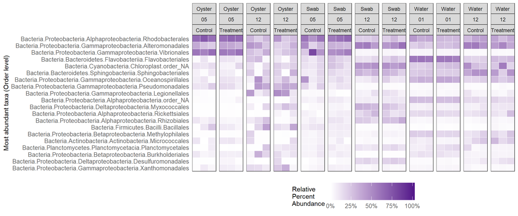

```r
library(plyr)

# order the abundance table by decreasing abundances
ordered_trial1_abund<-abund_table_t1[,order(colSums(abund_table_t1),decreasing=TRUE)]

#Extract list of top 20 Taxa
N<-20 # can change number of taxa to plot here
taxa_list<-colnames(ordered_trial1_abund)[1:N]
#Generate a new table with just top 20 most abundant.
new_abund_1<-data.frame(ordered_trial1_abund[,colnames(ordered_trial1_abund) %in% taxa_list])
#merge with metadata
trial1_topN<-as.data.frame(c(meta_table_t1, new_abund_1))
trial1_topN$SampleName<-trial1_topN$taxa
trial1_topNg<-gather(trial1_topN, taxa, value,
                     "Bacteria.Proteobacteria.Alphaproteobacteria.Rhodobacterales":
                       "Bacteria.Proteobacteria.Gammaproteobacteria.Xanthomonadales")
trial1_topNg_norm<-ddply(trial1_topNg,.(SampleName),transform,
                         rescale=sqrt(as.numeric(value)))
trial1_topNg_norm$taxa = factor(trial1_topNg_norm$taxa,
                                levels = rev(unique(trial1_topNg_norm$taxa)))


ggplot(trial1_topNg_norm, aes(SampleName, taxa)) +
  geom_tile(aes(fill = rescale),colour = "white") +
  facet_grid(~Type+Day+Treatment,space="free", scales="free")+
  #  scale_fill_gradient(na.value = "grey50",low="white",high="red")+
  scale_fill_gradientn(labels = scales::percent,limits=c(0,1),
                       colours=c("white", "purple4"))+
  scale_x_discrete(expand = c(0, 0)) +
  scale_y_discrete(expand = c(0, 0)) +
  theme(legend.position = "bottom",axis.ticks = element_blank(),
        axis.text.x = element_blank(),
        axis.text.y = element_text(size=10, colour="grey40"),
        legend.text = element_text(size=10, colour="grey40"),
        legend.key.size = unit(2, 'lines'))+
  labs(y="Most abundant taxa (Order level)", x=NULL, fill="Relative\nPercent\nAbundance")
```

**Supplementary Figure 2.** The relative abundances of the 20 most abundant orders in oyster, swab, and water samples from Trial 1.

### Figure S3. Water Types NMDS

This figure imports the raw hatchery inflow/outflow water and then plots it as an NMDS using Bray-Curtis beta-diversity.

```r
# see above in Figure 3 for details on methods below.

trial3all_abund<-read.xlsx("OysterHatcheryMicrobiome_orderdata.xlsx",sheet="trial3_all", rowNames = TRUE)
grouping_info_3w<-data.frame(row.names=rownames(trial3all_abund),
                             t(as.data.frame(strsplit(rownames(trial3all_abund),"_"))))

sol3w<-metaMDS(trial3all_abund,distance = "bray", k = 2, trymax = 50)
NMDS3w=data.frame(x=sol3w$point[,1],y=sol3w$point[,2],
                  Day=as.factor(grouping_info_3w[,1]),
                  Tank=as.factor(grouping_info_3w[,2]),Treatment=as.factor(grouping_info_3w[,3]))
plot.new()
ord3w<-ordiellipse(sol3w, as.factor(grouping_info_3w[,3]),
                   display = "sites", kind ="sd", conf = 0.95, label = T)
```

```r
dev.off()

veganCovEllipse<-function (cov, center = c(0, 0), scale = 1, npoints = 100)
{
  theta <- (0:npoints) * 2 * pi/npoints
  Circle <- cbind(cos(theta), sin(theta))
  t(center + scale * t(Circle %*% chol(cov)))
}

#Generate ellipse points
df_ell_3w <- data.frame()
for(g in levels(NMDS3w$Treatment)){
  if(g!="" && (g %in% names(ord3w))){
    df_ell_3w <- rbind(df_ell_3w, cbind(as.data.frame(with(NMDS3w[NMDS3w$Treatment==g,],
                veganCovEllipse(ord3w[[g]]$cov,ord3w[[g]]$center,ord3w[[g]]$scale))),Treatment=g))}}

NMDS3w.mean=aggregate(NMDS3w[,1:2],list(group=NMDS3w$Treatment),mean)
```

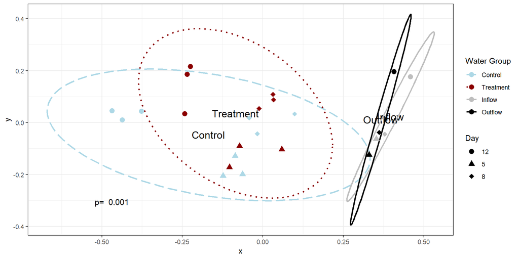

```r
# Calculate p-value:
adon_S3<-adonis2(trial3all_abund~X3, data=grouping_info_3w, by=NULL,method="bray", k=2)

# Plot the NMDS
NMDSplot_S3<-ggplot(data=NMDS3w,aes(x,y,colour=Treatment))+
  annotate("text",x=NMDS3w.mean$x,y=NMDS3w.mean$y,label=NMDS3w.mean$group,size=5)+
  annotate("text",x=min(NMDS3w$x),y=min(NMDS3w$y-0.1), label=paste("p= ", adon_S3$`Pr(>F)`[1]),size=4)+
  geom_path(data=df_ell_3w, aes(x=NMDS1, y=NMDS2, linetype=Treatment), size=1)+
  scale_linetype_manual(name="Water Group", limits=c("Control","Treatment", "Inflow","Outflow"),
                        values=c("longdash", "dotted", "solid", "solid"))+
  scale_colour_manual(name="Water Group", limits=c("Control","Treatment", "Inflow","Outflow"),
                      values=c("light blue", "dark red", "grey", "black"))+
  geom_point(aes(shape=Day), size=3) + scale_shape_manual(values=c(16,17,18)) +
  guides(color = guide_legend(order=1),lty= guide_legend(order=1),shape = guide_legend(order=2))

NMDSplot_S3
```

**Supplementary Figure 3.** NMDS plot visualization of Bray-Curtis beta-diversity (k=2) at the Order level by Treatment or Water Source of water samples from Trial 3. The ellipse lines show the 95% confidence interval. The water group is indicated by colors (control=light blue dashed, probiotic treatment=dark red dotted, inflow=grey solid, outflow=black solid) and sampling timepoints are indicated by symbols. The inflow water (water piped directly from the environment into the hatchery) and outflow water (inflow water UV-treated and sterilized) are significantly distinct groups, separate from the experimental samples. p-value indicates significance of groupings with adonis2 Permutational Multivariate Analysis of Variance Using Distance Matrices test.